# Concaténation des jeux de données

```python
import pandas as pd
import numpy as np
import matplotlib.pyplot as plt

pd.set_option("display.max_columns", None)
```

```python
# nb_posts = [0, 50_000, 100_000, 150_000, 200_000, 250_000, 300_000, 350_000,
#     400_000, 450_000, 500_000]

# posts_df = pd.DataFrame([])
# for i in range(1, len(nb_posts)):
#     posts_df = pd.concat([posts_df, pd.read_csv(f"Posts_{nb_posts[i -1]}_{nb_posts[i]}.csv")])

# posts_df.to_csv("P5_02_Posts_concat.csv", index= False)
```

```python
posts_df = pd.read_csv("P5_02_Posts_concat.csv")
```

```python
# nb_tags = [0, 50_000, 100_000, 150_000, "end"]

# tags_df = pd.DataFrame([])
# for i in range(1, len(nb_tags)):
#     tags_df = pd.concat([tags_df, pd.read_csv(f"Tags_{nb_tags[i -1]}_{nb_tags[i]}.csv")])

# tags_df.to_csv("P5_02_Tags_concat.csv", index= False)
```

```python
tags_df = pd.read_csv("P5_02_Tags_concat.csv")
```

```python
tagsynonyms_df = pd.read_csv("TagSynonyms.csv")
```

# Exploration des jeux de données

1. Jeu "TagSynonyms"
2. Jeu "Tags"
3. Jeu "Posts"

```python
print(f"TagSynonyms shape: {tagsynonyms_df.shape}")
tagsynonyms_df.columns
```

```
TagSynonyms shape: (5365, 10)
```

```
Index(['Id', 'SourceTagName', 'TargetTagName', 'CreationDate', 'OwnerUserId',
       'AutoRenameCount', 'LastAutoRename', 'Score', 'ApprovedByUserId',
       'ApprovalDate'],
      dtype='object')
```

```python
print(f"Tags shape: {tags_df.shape}")
tags_df.columns
```

```
Tags shape: (62255, 7)
```

```
Index(['Id', 'TagName', 'Count', 'ExcerptPostId', 'WikiPostId',
       'IsModeratorOnly', 'IsRequired'],
      dtype='object')
```

```python
print(f"Posts shape: {posts_df.shape}")

posts_df.columns
```

```
Posts shape: (338395, 23)
```

```
Index(['Id', 'PostTypeId', 'AcceptedAnswerId', 'ParentId', 'CreationDate',
       'DeletionDate', 'Score', 'ViewCount', 'Body', 'OwnerUserId',
       'OwnerDisplayName', 'LastEditorUserId', 'LastEditorDisplayName',
       'LastEditDate', 'LastActivityDate', 'Title', 'Tags', 'AnswerCount',
       'CommentCount', 'FavoriteCount', 'ClosedDate', 'CommunityOwnedDate',
       'ContentLicense'],
      dtype='object')
```

Toutes les colonnes ne sont pas nécessaires.

Dans un premier lieu, je vais afficher les jeux puis regarder les liens.

```python
tagsynonyms_df.head()
```

|  | Id | SourceTagName | TargetTagName | CreationDate | OwnerUserId | AutoRenameCount | LastAutoRename | Score | ApprovedByUserId | ApprovalDate |
| --- | --- | --- | --- | --- | --- | --- | --- | --- | --- | --- |
| 0 | 3 | windows-forms | winforms | 2010-07-14 06:34:55 | 23354 | 679 | 2021-12-15 15:48:08 | 0 | 23354.0 | 2010-07-14 06:34:55 |
| 1 | 5 | c-sharp | c# | 2010-07-14 22:30:24 | 17174 | 228 | 2021-12-13 20:30:24 | 0 | 17174.0 | 2010-07-14 22:30:24 |
| 2 | 7 | hg | mercurial | 2010-07-15 22:46:06 | 17174 | 1045 | 2021-12-09 15:49:35 | 0 | 17174.0 | 2010-07-15 22:46:06 |
| 3 | 9 | dotnet | .net | 2010-07-16 00:02:29 | 17174 | 2814 | 2021-12-18 11:37:12 | 0 | 17174.0 | 2010-07-16 00:02:29 |
| 4 | 10 | threading | multithreading | 2010-07-16 00:04:00 | 17174 | 5089 | 2021-12-16 16:17:03 | 0 | 17174.0 | 2010-07-16 00:04:00 |

```python
tags_df.head()
```

|  | Id | TagName | Count | ExcerptPostId | WikiPostId | IsModeratorOnly | IsRequired |
| --- | --- | --- | --- | --- | --- | --- | --- |
| 0 | 1 | .net | 313668 | 3624959.0 | 3607476.0 | NaN | NaN |
| 1 | 2 | html | 1105155 | 3673183.0 | 3673182.0 | NaN | NaN |
| 2 | 3 | javascript | 2310521 | 3624960.0 | 3607052.0 | NaN | NaN |
| 3 | 4 | css | 742245 | 3644670.0 | 3644669.0 | NaN | NaN |
| 4 | 5 | php | 1423317 | 3624936.0 | 3607050.0 | NaN | NaN |

```python
posts_df.head()
```

|  | Id | PostTypeId | AcceptedAnswerId | ParentId | CreationDate | DeletionDate | Score | ViewCount | Body | OwnerUserId | OwnerDisplayName | LastEditorUserId | LastEditorDisplayName | LastEditDate | LastActivityDate | Title | Tags | AnswerCount | CommentCount | FavoriteCount | ClosedDate | CommunityOwnedDate | ContentLicense |
| --- | --- | --- | --- | --- | --- | --- | --- | --- | --- | --- | --- | --- | --- | --- | --- | --- | --- | --- | --- | --- | --- | --- | --- |
| 0 | 4 | 1 | 7.0 | NaN | 2008-07-31 21:42:52 | NaN | 745 | 62032.0 | <p>I want to use a <code>Track-Bar</code> to c... | 8.0 | NaN | 3072350.0 | Rich B | 2021-02-26 03:31:15 | 2021-11-15 21:15:29 | How to convert a Decimal to a Double in C#? | <c#><floating-point><type-conversion><double><... | 12.0 | 3 | 59.0 | NaN | 2012-10-31 16:42:47 | CC BY-SA 4.0 |
| 1 | 6 | 1 | 31.0 | NaN | 2008-07-31 22:08:08 | NaN | 310 | 22237.0 | <p>I have an absolutely positioned <code>div</... | 9.0 | NaN | 9134576.0 | user14723686 | 2021-01-29 18:46:45 | 2021-01-29 18:46:45 | Why did the width collapse in the percentage w... | <html><css><internet-explorer-7> | 7.0 | 0 | 13.0 | NaN | NaN | CC BY-SA 4.0 |
| 2 | 7 | 2 | NaN | 4.0 | 2008-07-31 22:17:57 | NaN | 496 | NaN | <p>An explicit cast to <code>double</code> lik... | 9.0 | NaN | 5496973.0 | NaN | 2019-10-21 14:03:54 | 2019-10-21 14:03:54 | NaN | NaN | NaN | 0 | NaN | NaN | NaN | CC BY-SA 4.0 |
| 3 | 9 | 1 | 1404.0 | NaN | 2008-07-31 23:40:59 | NaN | 2072 | 711798.0 | <p>Given a <code>DateTime</code> representing ... | 1.0 | NaN | 6537157.0 | Rich B | 2021-01-05 17:33:32 | 2021-11-15 21:33:05 | How do I calculate someone's age based on a Da... | <c#><.net><datetime> | 68.0 | 10 | 483.0 | NaN | 2011-08-16 19:40:43 | CC BY-SA 4.0 |
| 4 | 11 | 1 | 1248.0 | NaN | 2008-07-31 23:55:37 | NaN | 1597 | 185139.0 | <p>Given a specific <code>DateTime</code> valu... | 1.0 | NaN | 6479704.0 | user2370523 | 2017-06-04 15:51:19 | 2021-09-01 21:49:09 | Calculate relative time in C# | <c#><datetime><time><datediff><relative-time-s... | 40.0 | 3 | 552.0 | NaN | 2009-09-04 13:15:59 | CC BY-SA 3.0 |

"TargetTagName" correspond à "TagName" et "Tags" de respectivement "tagsynonyms_df", "tags_df" et "posts_df".

Colonnes intéressantes pour le jeu:

1. tagsynonyms_df:
   1. Id
   2. SourceTagName
   3. TargetTagName
2. tags_df:
   1. Id
   2. TagName
3. posts_df:
   1. Id
   2. Body
   3. Title
   4. Tags

Je peux droper toutes les autres colonnes et je vais merger "tagsynonyms_df" et "tags_df" sur "TargetTagName" et "TagName.

```python
tagsynonyms_ddf = tagsynonyms_df.drop([x for x in tagsynonyms_df.columns if x not in ["Id",
    "SourceTagName", "TargetTagName"]], axis=1)
tags_ddf = tags_df.drop([x for x in tags_df.columns if x not in ["Id", "TagName"]], axis= 1)
posts_ddf = posts_df.drop([x for x in posts_df.columns if x not in ["Id", "Body", "Title",
    "Tags", "Score", "ViewCount", "AnswerCount", "FavoriteCount", ]], axis= 1)
```

```python
tags_ddf = tags_ddf[tags_ddf["TagName"].notna()]
```

```python
f_tags_df = tags_ddf.merge(tagsynonyms_ddf, how= "left", left_on= "TagName", right_on=
    "TargetTagName")

f_tags_df
```

|  | Id_x | TagName | Id_y | SourceTagName | TargetTagName |
| --- | --- | --- | --- | --- | --- |
| 0 | 1 | .net | 9.0 | dotnet | .net |
| 1 | 1 | .net | 775.0 | dot-net | .net |
| 2 | 1 | .net | 2684.0 | .net-framework | .net |
| 3 | 2 | html | 3925.0 | html-tag | html |
| 4 | 2 | html | 4536.0 | html-attributes | html |
| ... | ... | ... | ... | ... | ... |
| 64236 | 154159 | kronecker-product | NaN | NaN | NaN |
| 64237 | 154160 | simple-realtime-server | NaN | NaN | NaN |
| 64238 | 154161 | samsung | NaN | NaN | NaN |
| 64239 | 154162 | startforegroundservice | NaN | NaN | NaN |
| 64240 | 154163 | constraintlayout | NaN | NaN | NaN |

64241 rows × 5 columns

```python
# f_tags_df.to_csv("P5_02_Tags_merged.csv", index= False)
```

```python
posts_ddf.reset_index(drop= True, inplace= True)

posts_ddf
```

|  | Id | Score | ViewCount | Body | Title | Tags | AnswerCount | FavoriteCount |
| --- | --- | --- | --- | --- | --- | --- | --- | --- |
| 0 | 4 | 745 | 62032.0 | <p>I want to use a <code>Track-Bar</code> to c... | How to convert a Decimal to a Double in C#? | <c#><floating-point><type-conversion><double><... | 12.0 | 59.0 |
| 1 | 6 | 310 | 22237.0 | <p>I have an absolutely positioned <code>div</... | Why did the width collapse in the percentage w... | <html><css><internet-explorer-7> | 7.0 | 13.0 |
| 2 | 7 | 496 | NaN | <p>An explicit cast to <code>double</code> lik... | NaN | NaN | NaN | NaN |
| 3 | 9 | 2072 | 711798.0 | <p>Given a <code>DateTime</code> representing ... | How do I calculate someone's age based on a Da... | <c#><.net><datetime> | 68.0 | 483.0 |
| 4 | 11 | 1597 | 185139.0 | <p>Given a specific <code>DateTime</code> valu... | Calculate relative time in C# | <c#><datetime><time><datediff><relative-time-s... | 40.0 | 552.0 |
| ... | ... | ... | ... | ... | ... | ... | ... | ... |
| 338390 | 499991 | 2 | NaN | <p>Don't meddle with core types. Never stick s... | NaN | NaN | NaN | NaN |
| 338391 | 499994 | 3 | NaN | <p>I prefer to use "Hansel and Gretel" type co... | NaN | NaN | NaN | NaN |
| 338392 | 499995 | 63 | 73800.0 | <p>I read on here of an exercise in interviews... | How do you validate a binary search tree? | <algorithm><data-structures><binary-search-tree> | 32.0 | 44.0 |
| 338393 | 499997 | 1 | 3283.0 | <p>This MVC stuff is fun but every step along ... | Is Request.IsAjaxRequest() broken in the MVC R... | <asp.net-mvc><asp.net-ajax> | 3.0 | NaN |
| 338394 | 499998 | 0 | NaN | <p>I comment as much as needed - then, as much... | NaN | NaN | NaN | NaN |

338395 rows × 8 columns

Il faut commencer par cleaner la colonne "Body" en retirant les balises html.

```python
from bs4 import BeautifulSoup

posts_ddf["Body"] = posts_ddf["Body"].apply(lambda x:
    BeautifulSoup(x).get_text())

# posts_ddf
```

Je vais enregistrer ce jeu dont les balises html ont été retirées.

```python
# posts_ddf.to_csv("P5_02_Posts_HTML_cleaned.csv", index= False)
```

```python
posts_ddf = pd.read_csv("P5_02_Posts_HTML_cleaned.csv")

posts_ddf
```

|  | Id | Score | ViewCount | Body | Title | Tags | AnswerCount | FavoriteCount |
| --- | --- | --- | --- | --- | --- | --- | --- | --- |
| 0 | 4 | 745 | 62032.0 | I want to use a Track-Bar to change a Form's o... | How to convert a Decimal to a Double in C#? | <c#><floating-point><type-conversion><double><... | 12.0 | 59.0 |
| 1 | 6 | 310 | 22237.0 | I have an absolutely positioned div containing... | Why did the width collapse in the percentage w... | <html><css><internet-explorer-7> | 7.0 | 13.0 |
| 2 | 7 | 496 | NaN | An explicit cast to double like this isn't nec... | NaN | NaN | NaN | NaN |
| 3 | 9 | 2072 | 711798.0 | Given a DateTime representing a person's birth... | How do I calculate someone's age based on a Da... | <c#><.net><datetime> | 68.0 | 483.0 |
| 4 | 11 | 1597 | 185139.0 | Given a specific DateTime value, how do I disp... | Calculate relative time in C# | <c#><datetime><time><datediff><relative-time-s... | 40.0 | 552.0 |
| ... | ... | ... | ... | ... | ... | ... | ... | ... |
| 338390 | 499991 | 2 | NaN | Don't meddle with core types. Never stick some... | NaN | NaN | NaN | NaN |
| 338391 | 499994 | 3 | NaN | I prefer to use "Hansel and Gretel" type comme... | NaN | NaN | NaN | NaN |
| 338392 | 499995 | 63 | 73800.0 | I read on here of an exercise in interviews kn... | How do you validate a binary search tree? | <algorithm><data-structures><binary-search-tree> | 32.0 | 44.0 |
| 338393 | 499997 | 1 | 3283.0 | This MVC stuff is fun but every step along the... | Is Request.IsAjaxRequest() broken in the MVC R... | <asp.net-mvc><asp.net-ajax> | 3.0 | NaN |
| 338394 | 499998 | 0 | NaN | I comment as much as needed - then, as much as... | NaN | NaN | NaN | NaN |

338395 rows × 8 columns

Les individus qui m'intéressent sont ceux avec des tags. Je vais donc supprimer les autres.

```python
posts_tagged_df = posts_ddf[posts_ddf["Tags"].notna()].reset_index(drop= True)

posts_tagged_df
```

|  | Id | Score | ViewCount | Body | Title | Tags | AnswerCount | FavoriteCount |
| --- | --- | --- | --- | --- | --- | --- | --- | --- |
| 0 | 4 | 745 | 62032.0 | I want to use a Track-Bar to change a Form's o... | How to convert a Decimal to a Double in C#? | <c#><floating-point><type-conversion><double><... | 12.0 | 59.0 |
| 1 | 6 | 310 | 22237.0 | I have an absolutely positioned div containing... | Why did the width collapse in the percentage w... | <html><css><internet-explorer-7> | 7.0 | 13.0 |
| 2 | 9 | 2072 | 711798.0 | Given a DateTime representing a person's birth... | How do I calculate someone's age based on a Da... | <c#><.net><datetime> | 68.0 | 483.0 |
| 3 | 11 | 1597 | 185139.0 | Given a specific DateTime value, how do I disp... | Calculate relative time in C# | <c#><datetime><time><datediff><relative-time-s... | 40.0 | 552.0 |
| 4 | 13 | 667 | 240907.0 | Is there a standard way for a web server to be... | Determine a user's timezone | <html><browser><timezone><user-agent><timezone... | 26.0 | 157.0 |
| ... | ... | ... | ... | ... | ... | ... | ... | ... |
| 73763 | 499977 | 0 | 137.0 | I created a small VS solution that includes WF... | How to code hosting of the WF with WC 3.5 Reci... | <windows><wcf><service><hosting><workflow-foun... | 1.0 | NaN |
| 73764 | 499987 | 0 | 898.0 | I added a simple dialog window to the install'... | How to access information entered during setup... | <.net><visual-studio><installation><windows-in... | 1.0 | NaN |
| 73765 | 499989 | 1 | 3246.0 | I have my own php data object class that wraps... | Mysql MediumText causes PHP Fatal error: Allow... | <php><memory-management> | 3.0 | NaN |
| 73766 | 499995 | 63 | 73800.0 | I read on here of an exercise in interviews kn... | How do you validate a binary search tree? | <algorithm><data-structures><binary-search-tree> | 32.0 | 44.0 |
| 73767 | 499997 | 1 | 3283.0 | This MVC stuff is fun but every step along the... | Is Request.IsAjaxRequest() broken in the MVC R... | <asp.net-mvc><asp.net-ajax> | 3.0 | NaN |

73768 rows × 8 columns

```python
posts_tagged_df["Title"].isnull().sum()
```

```
1
```

```python
posts_tagged_df["Title"] = posts_tagged_df["Title"].fillna(" ")
```

```python
posts_tagged_df["Title"].isnull().sum()
```

```
0
```

Réunion du titre et du corps du post et mise du tout en minuscules.

```python
posts_tagged_df.insert(1, "full_posts", posts_tagged_df["Title"].str.lower() + " " + posts_tagged_df["Body"].str.lower())

posts_tagged_df
```

|  | Id | full_posts | Score | ViewCount | Body | Title | Tags | AnswerCount | FavoriteCount |
| --- | --- | --- | --- | --- | --- | --- | --- | --- | --- |
| 0 | 4 | how to convert a decimal to a double in c#? i ... | 745 | 62032.0 | I want to use a Track-Bar to change a Form's o... | How to convert a Decimal to a Double in C#? | <c#><floating-point><type-conversion><double><... | 12.0 | 59.0 |
| 1 | 6 | why did the width collapse in the percentage w... | 310 | 22237.0 | I have an absolutely positioned div containing... | Why did the width collapse in the percentage w... | <html><css><internet-explorer-7> | 7.0 | 13.0 |
| 2 | 9 | how do i calculate someone's age based on a da... | 2072 | 711798.0 | Given a DateTime representing a person's birth... | How do I calculate someone's age based on a Da... | <c#><.net><datetime> | 68.0 | 483.0 |
| 3 | 11 | calculate relative time in c# given a specific... | 1597 | 185139.0 | Given a specific DateTime value, how do I disp... | Calculate relative time in C# | <c#><datetime><time><datediff><relative-time-s... | 40.0 | 552.0 |
| 4 | 13 | determine a user's timezone is there a standar... | 667 | 240907.0 | Is there a standard way for a web server to be... | Determine a user's timezone | <html><browser><timezone><user-agent><timezone... | 26.0 | 157.0 |
| ... | ... | ... | ... | ... | ... | ... | ... | ... | ... |
| 73763 | 499977 | how to code hosting of the wf with wc 3.5 reci... | 0 | 137.0 | I created a small VS solution that includes WF... | How to code hosting of the WF with WC 3.5 Reci... | <windows><wcf><service><hosting><workflow-foun... | 1.0 | NaN |
| 73764 | 499987 | how to access information entered during setup... | 0 | 898.0 | I added a simple dialog window to the install'... | How to access information entered during setup... | <.net><visual-studio><installation><windows-in... | 1.0 | NaN |
| 73765 | 499989 | mysql mediumtext causes php fatal error: allow... | 1 | 3246.0 | I have my own php data object class that wraps... | Mysql MediumText causes PHP Fatal error: Allow... | <php><memory-management> | 3.0 | NaN |
| 73766 | 499995 | how do you validate a binary search tree? i re... | 63 | 73800.0 | I read on here of an exercise in interviews kn... | How do you validate a binary search tree? | <algorithm><data-structures><binary-search-tree> | 32.0 | 44.0 |
| 73767 | 499997 | is request.isajaxrequest() broken in the mvc r... | 1 | 3283.0 | This MVC stuff is fun but every step along the... | Is Request.IsAjaxRequest() broken in the MVC R... | <asp.net-mvc><asp.net-ajax> | 3.0 | NaN |

73768 rows × 9 columns

Drop de "Body" et "Title".

```python
posts_tagged_df.drop(["Body", "Title"], axis= 1, inplace= True)
```

```python
import re

def ponctuations(post):
    words_list = []
    splited_post = post.split()
    for word in splited_post:
        # word = re.sub(r'-', " ", word)
        word = re.sub(r'\.$', " ", word)
        word = re.sub(r'\.{2,}', " ", word)
        word = re.sub(r'\+{1}', " ", word)
        word = re.sub(r'\'s', " is", word)
        word = re.sub(r'n\'t', " not", word)

        words_list.append(word)

    return " ".join(words_list)
```

```python
tmp_df = posts_tagged_df["full_posts"].apply(lambda x: ponctuations(x))

tmp_df
```

```
0        how to convert a decimal to a double in c#? i ...
1        why did the width collapse in the percentage w...
2        how do i calculate someone is age based on a d...
3        calculate relative time in c# given a specific...
4        determine a user is timezone is there a standa...
                               ...
73763    how to code hosting of the wf with wc 3.5 reci...
73764    how to access information entered during setup...
73765    mysql mediumtext causes php fatal error: allow...
73766    how do you validate a binary search tree? i re...
73767    is request.isajaxrequest() broken in the mvc r...
Name: full_posts, Length: 73768, dtype: object
```

```python
tmp_df[0]
```

```
'how to convert a decimal to a double in c#? i want to use a track-bar to change a form is opacity  this is my code: decimal trans = trackbar1.value / 5000; this.opacity = trans; when i build the application, it gives the following error: cannot implicitly convert type decimal to double i have tried…
```

```python
from nltk import RegexpTokenizer
from nltk.corpus import stopwords

# full_nb_words = np.zeros(len(posts_tagged_df))
# no_stops_nb_words = np.zeros(len(posts_tagged_df))
# count = 0

def remove_stopwords(post, tokenizer, stops):

    words = tokenizer.tokenize(post)
    words = [w for w in words if not w.isnumeric()]
    words = [w for w in words if len(w) > 1]

    important_words = [x for x in words if x not in stops]
    important_words = [w for w in important_words if not w.isnumeric()]
    important_words = [w for w in important_words if len(w) > 1]

    return np.array([" ".join(words), " ".join(important_words)])
```

```python
stops = set(stopwords.words("english"))

regex_form = r'[a-zA-Z0-9]+\.{1}[a-zA-Z0-9]+|[a-zA-Z]+\#?\+*|[a-zA-Z0-9]+\-*[a-zA-Z0-9]*|\.?[a-zA-Z]+'
tokenizer = RegexpTokenizer(regex_form)

tmp_dff = tmp_df.apply(lambda x:
    remove_stopwords(x, tokenizer, stops))
```

```python
tmp_dff[0]
```

```
array(['how to convert decimal to double in c# want to use track bar to change form is opacity this is my code decimal trans trackbar1.value this.opacity trans when build the application it gives the following error cannot implicitly convert type decimal to double have tried using trans and double b…
       'convert decimal double c# want use track bar change form opacity code decimal trans trackbar1.value this.opacity trans build application gives following error cannot implicitly convert type decimal double tried using trans double control work code worked fine past vb.net project'],
      dtype='<U370')
```

```python
posts_tagged_df[["full_posts", "no_stops_posts"]] = pd.DataFrame(tmp_dff.tolist(),
    index= posts_tagged_df.index)

# posts_tagged_df["full_nb_words"] = full_nb_words
# posts_tagged_df["no_stop_nb_words"] = no_stops_nb_words

posts_tagged_df
```

|  | Id | full_posts | Score | ViewCount | Tags | AnswerCount | FavoriteCount | no_stops_posts |
| --- | --- | --- | --- | --- | --- | --- | --- | --- |
| 0 | 4 | how to convert decimal to double in c# want to... | 745 | 62032.0 | <c#><floating-point><type-conversion><double><... | 12.0 | 59.0 | convert decimal double c# want use track bar c... |
| 1 | 6 | why did the width collapse in the percentage w... | 310 | 22237.0 | <html><css><internet-explorer-7> | 7.0 | 13.0 | width collapse percentage width child element ... |
| 2 | 9 | how do calculate someone is age based on datet... | 2072 | 711798.0 | <c#><.net><datetime> | 68.0 | 483.0 | calculate someone age based datetime type birt... |
| 3 | 11 | calculate relative time in c# given specific d... | 1597 | 185139.0 | <c#><datetime><time><datediff><relative-time-s... | 40.0 | 552.0 | calculate relative time c# given specific date... |
| 4 | 13 | determine user is timezone is there standard w... | 667 | 240907.0 | <html><browser><timezone><user-agent><timezone... | 26.0 | 157.0 | determine user timezone standard way web serve... |
| ... | ... | ... | ... | ... | ... | ... | ... | ... |
| 73763 | 499977 | how to code hosting of the wf with wc 3.5 reci... | 0 | 137.0 | <windows><wcf><service><hosting><workflow-foun... | 1.0 | NaN | code hosting wf wc 3.5 reciveactivity windows ... |
| 73764 | 499987 | how to access information entered during setup... | 0 | 898.0 | <.net><visual-studio><installation><windows-in... | 1.0 | NaN | access information entered setup vs setup proj... |
| 73765 | 499989 | mysql mediumtext causes php fatal error allowe... | 1 | 3246.0 | <php><memory-management> | 3.0 | NaN | mysql mediumtext causes php fatal error allowe... |
| 73766 | 499995 | how do you validate binary search tree read on... | 63 | 73800.0 | <algorithm><data-structures><binary-search-tree> | 32.0 | 44.0 | validate binary search tree read exercise inte... |
| 73767 | 499997 | is request.isajaxrequest broken in the mvc rc ... | 1 | 3283.0 | <asp.net-mvc><asp.net-ajax> | 3.0 | NaN | request.isajaxrequest broken mvc rc refresh mv... |

73768 rows × 8 columns

Je veux les posts les plus pertinents.

Pour commencer, je vais garder les posts étant en favoris au moins 1 fois, avec un score > 0 et ayant au moins une réponse.

```python
posts_tagged_df = posts_tagged_df[(posts_tagged_df["FavoriteCount"].notna()) &
    (posts_tagged_df["FavoriteCount"] > 0) & (posts_tagged_df["Score"] > 0) &
    (posts_tagged_df["AnswerCount"] > 0)].reset_index(drop= True)

posts_tagged_df
```

|  | Id | full_posts | Score | ViewCount | Tags | AnswerCount | FavoriteCount | no_stops_posts |
| --- | --- | --- | --- | --- | --- | --- | --- | --- |
| 0 | 4 | how to convert decimal to double in c# want to... | 745 | 62032.0 | <c#><floating-point><type-conversion><double><... | 12.0 | 59.0 | convert decimal double c# want use track bar c... |
| 1 | 6 | why did the width collapse in the percentage w... | 310 | 22237.0 | <html><css><internet-explorer-7> | 7.0 | 13.0 | width collapse percentage width child element ... |
| 2 | 9 | how do calculate someone is age based on datet... | 2072 | 711798.0 | <c#><.net><datetime> | 68.0 | 483.0 | calculate someone age based datetime type birt... |
| 3 | 11 | calculate relative time in c# given specific d... | 1597 | 185139.0 | <c#><datetime><time><datediff><relative-time-s... | 40.0 | 552.0 | calculate relative time c# given specific date... |
| 4 | 13 | determine user is timezone is there standard w... | 667 | 240907.0 | <html><browser><timezone><user-agent><timezone... | 26.0 | 157.0 | determine user timezone standard way web serve... |
| ... | ... | ... | ... | ... | ... | ... | ... | ... |
| 44850 | 499964 | how do you create python methods signature and... | 4 | 2893.0 | <python><django><dynamic><methods><lambda> | 1.0 | 2.0 | create python methods signature content code c... |
| 44851 | 499966 | etag vs header expires ve looked around but ha... | 366 | 136111.0 | <http><caching><etag><expires-header> | 7.0 | 225.0 | etag vs header expires looked around able figu... |
| 44852 | 499967 | how do determine the longest similar portion o... | 9 | 7151.0 | <perl><algorithm><string><similarity> | 7.0 | 4.0 | determine longest similar portion several stri... |
| 44853 | 499974 | powershell can you hook or intercept powershel... | 2 | 1381.0 | <command-line><powershell><user-interface> | 2.0 | 2.0 | powershell hook intercept powershell execution... |
| 44854 | 499995 | how do you validate binary search tree read on... | 63 | 73800.0 | <algorithm><data-structures><binary-search-tree> | 32.0 | 44.0 | validate binary search tree read exercise inte... |

44855 rows × 8 columns

Je vais maintenant regarder la répartition de "ViewCount" et "AnswerCount" et garder les posts avec le plus d'impact.

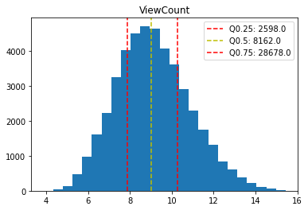

```python
viewcount_log = np.log(posts_tagged_df["ViewCount"])
quantile_vals = [0.25, 0.5, 0.75]
q_view_log = np.quantile(viewcount_log, quantile_vals)
q_view = np.quantile(np.round(np.exp(viewcount_log)), quantile_vals)

colors = {0: "r", 1: "y", 2: "r"}

plt.hist(viewcount_log, bins= 25)
for i in range(len(q_view_log)):
    plt.axvline(q_view_log[i], ls= "--", c= colors[i], label= f"Q{quantile_vals[i]}: {q_view[i]}")

plt.title("ViewCount")
plt.legend()

plt.show()
```

Je vais exclure les 25% des posts les moins pertinents donc avec moins de 2598 vues.

```python
posts_tagged_df = posts_tagged_df[posts_tagged_df["ViewCount"] > 2598].reset_index(drop= True)

posts_tagged_df
```

|  | Id | full_posts | Score | ViewCount | Tags | AnswerCount | FavoriteCount | no_stops_posts |
| --- | --- | --- | --- | --- | --- | --- | --- | --- |
| 0 | 4 | how to convert decimal to double in c# want to... | 745 | 62032.0 | <c#><floating-point><type-conversion><double><... | 12.0 | 59.0 | convert decimal double c# want use track bar c... |
| 1 | 6 | why did the width collapse in the percentage w... | 310 | 22237.0 | <html><css><internet-explorer-7> | 7.0 | 13.0 | width collapse percentage width child element ... |
| 2 | 9 | how do calculate someone is age based on datet... | 2072 | 711798.0 | <c#><.net><datetime> | 68.0 | 483.0 | calculate someone age based datetime type birt... |
| 3 | 11 | calculate relative time in c# given specific d... | 1597 | 185139.0 | <c#><datetime><time><datediff><relative-time-s... | 40.0 | 552.0 | calculate relative time c# given specific date... |
| 4 | 13 | determine user is timezone is there standard w... | 667 | 240907.0 | <html><browser><timezone><user-agent><timezone... | 26.0 | 157.0 | determine user timezone standard way web serve... |
| ... | ... | ... | ... | ... | ... | ... | ... | ... |
| 33635 | 499949 | flash loads twice workaround while investigati... | 7 | 3619.0 | <flash><swfobject> | 3.0 | 2.0 | flash loads twice workaround investigating rep... |
| 33636 | 499964 | how do you create python methods signature and... | 4 | 2893.0 | <python><django><dynamic><methods><lambda> | 1.0 | 2.0 | create python methods signature content code c... |
| 33637 | 499966 | etag vs header expires ve looked around but ha... | 366 | 136111.0 | <http><caching><etag><expires-header> | 7.0 | 225.0 | etag vs header expires looked around able figu... |
| 33638 | 499967 | how do determine the longest similar portion o... | 9 | 7151.0 | <perl><algorithm><string><similarity> | 7.0 | 4.0 | determine longest similar portion several stri... |
| 33639 | 499995 | how do you validate binary search tree read on... | 63 | 73800.0 | <algorithm><data-structures><binary-search-tree> | 32.0 | 44.0 | validate binary search tree read exercise inte... |

33640 rows × 8 columns

Voyons ce que donne "AnswerCount".

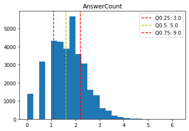

```python
answercount_log = np.log(posts_tagged_df["AnswerCount"])
q_answer_log = np.quantile(answercount_log, quantile_vals)
q_answer = np.quantile(np.round(np.exp(answercount_log)), quantile_vals)

plt.hist(answercount_log, bins= 25)
for i in range(len(q_answer_log)):
    plt.axvline(q_answer_log[i], ls= "--", c= colors[i], label= f"Q{quantile_vals[i]}: {q_answer[i]}")

plt.title("AnswerCount")
plt.legend()

plt.show()
```

Je vais appliquer le même principe que précédemment avec des posts ayant moins de 3 réponses.

```python
posts_tagged_df = posts_tagged_df[posts_tagged_df["AnswerCount"] >= 3].reset_index(drop= True)

posts_tagged_df
```

|  | Id | full_posts | Score | ViewCount | Tags | AnswerCount | FavoriteCount | no_stops_posts |
| --- | --- | --- | --- | --- | --- | --- | --- | --- |
| 0 | 4 | how to convert decimal to double in c# want to... | 745 | 62032.0 | <c#><floating-point><type-conversion><double><... | 12.0 | 59.0 | convert decimal double c# want use track bar c... |
| 1 | 6 | why did the width collapse in the percentage w... | 310 | 22237.0 | <html><css><internet-explorer-7> | 7.0 | 13.0 | width collapse percentage width child element ... |
| 2 | 9 | how do calculate someone is age based on datet... | 2072 | 711798.0 | <c#><.net><datetime> | 68.0 | 483.0 | calculate someone age based datetime type birt... |
| 3 | 11 | calculate relative time in c# given specific d... | 1597 | 185139.0 | <c#><datetime><time><datediff><relative-time-s... | 40.0 | 552.0 | calculate relative time c# given specific date... |
| 4 | 13 | determine user is timezone is there standard w... | 667 | 240907.0 | <html><browser><timezone><user-agent><timezone... | 26.0 | 157.0 | determine user timezone standard way web serve... |
| ... | ... | ... | ... | ... | ... | ... | ... | ... |
| 29096 | 499939 | how to extract the decimal part from floating ... | 60 | 248549.0 | <c><floating-point><decimal><numbers> | 15.0 | 15.0 | extract decimal part floating point number ext... |
| 29097 | 499949 | flash loads twice workaround while investigati... | 7 | 3619.0 | <flash><swfobject> | 3.0 | 2.0 | flash loads twice workaround investigating rep... |
| 29098 | 499966 | etag vs header expires ve looked around but ha... | 366 | 136111.0 | <http><caching><etag><expires-header> | 7.0 | 225.0 | etag vs header expires looked around able figu... |
| 29099 | 499967 | how do determine the longest similar portion o... | 9 | 7151.0 | <perl><algorithm><string><similarity> | 7.0 | 4.0 | determine longest similar portion several stri... |
| 29100 | 499995 | how do you validate binary search tree read on... | 63 | 73800.0 | <algorithm><data-structures><binary-search-tree> | 32.0 | 44.0 | validate binary search tree read exercise inte... |

29101 rows × 8 columns

```python
random_ind = np.random.choice(len(posts_tagged_df), 1)

posts_tagged_df.loc[random_ind, ["Tags", "no_stops_posts"]]
```

|  | Tags | no_stops_posts |
| --- | --- | --- |
| 11586 | <c#><.net><winapi> | c# intptr win wndproc syntax calling subclassi... |

Grâce à "TagSynonyms.csv", je transforme les mots des posts similaires à des tags par leur tag associé.

```python
tags_synonyms = pd.read_csv("TagSynonyms.csv")
tags_synonyms
```

|  | Id | SourceTagName | TargetTagName | CreationDate | OwnerUserId | AutoRenameCount | LastAutoRename | Score | ApprovedByUserId | ApprovalDate |
| --- | --- | --- | --- | --- | --- | --- | --- | --- | --- | --- |
| 0 | 3 | windows-forms | winforms | 2010-07-14 06:34:55 | 23354 | 679 | 2021-12-15 15:48:08 | 0 | 23354.0 | 2010-07-14 06:34:55 |
| 1 | 5 | c-sharp | c# | 2010-07-14 22:30:24 | 17174 | 228 | 2021-12-13 20:30:24 | 0 | 17174.0 | 2010-07-14 22:30:24 |
| 2 | 7 | hg | mercurial | 2010-07-15 22:46:06 | 17174 | 1045 | 2021-12-09 15:49:35 | 0 | 17174.0 | 2010-07-15 22:46:06 |
| 3 | 9 | dotnet | .net | 2010-07-16 00:02:29 | 17174 | 2814 | 2021-12-18 11:37:12 | 0 | 17174.0 | 2010-07-16 00:02:29 |
| 4 | 10 | threading | multithreading | 2010-07-16 00:04:00 | 17174 | 5089 | 2021-12-16 16:17:03 | 0 | 17174.0 | 2010-07-16 00:04:00 |
| ... | ... | ... | ... | ... | ... | ... | ... | ... | ... | ... |
| 5360 | 8403 | adobe-launch | adobe-dtm | 2021-12-12 16:47:57 | 184595 | 0 | NaN | 0 | NaN | NaN |
| 5361 | 8404 | ietf-netmod-yang | yang | 2021-12-15 08:30:51 | 878469 | 0 | NaN | 0 | NaN | NaN |
| 5362 | 8405 | netconf | ietf-netconf | 2021-12-15 08:33:00 | 878469 | 0 | NaN | 0 | NaN | NaN |
| 5363 | 8406 | dart | flutter | 2021-12-15 11:01:52 | 13997210 | 0 | NaN | 0 | NaN | NaN |
| 5364 | 8407 | ptree | boost-propertytree | 2021-12-15 16:17:41 | 85371 | 0 | NaN | 0 | NaN | NaN |

5365 rows × 10 columns

```python
counter = 0

def transform_words(splitted_words):
    global counter

    if (counter +1) % 1000 == 0:
        print(f"{counter +1}/{len(posts_tagged_df)}")

    resulting_words = []
    for word in splitted_words:
        if word in tags_synonyms["SourceTagName"].values:
            new_word = str(tags_synonyms.loc[tags_synonyms["SourceTagName"] == word, "TargetTagName"].values[0])
            resulting_words.append(new_word)
        # elif word in tags_synonyms["TargetTagName"].values:
        else:
            resulting_words.append(word)

    counter += 1
    # print(resulting_words)
    return " ".join(resulting_words)
```

```python
posts_tagged_df["no_stops_posts"] = posts_tagged_df["no_stops_posts"].apply(lambda x: transform_words(x.split()))
```

```
1000/29101
2000/29101
3000/29101
4000/29101
5000/29101
6000/29101
7000/29101
8000/29101
9000/29101
10000/29101
11000/29101
12000/29101
13000/29101
14000/29101
15000/29101
16000/29101
17000/29101
18000/29101
19000/29101
20000/29101
21000/29101
22000/29101
23000/29101
24000/29101
25000/29101
26000/29101
27000/29101
28000/29101
29000/29101
```

```python
random_ind = np.random.choice(len(posts_tagged_df), 1)

posts_tagged_df.loc[random_ind, "no_stops_posts"].values
```

```
array(['uinavigationbar tintcolor gradient like change programmaticaly tintcolor uinavigationbar keep gradient interface builder change tintcolor code gradient disappears change tintcolor interface builder gradient kept ideas'],
      dtype=object)
```

```python
posts_tagged_df.to_csv("P5_02_Posts_final.csv", index= False)
```